# Large-scale experiment

This notebook contains the code of the paper "Learning Physics between Digital Twins with Low-Fidelity Models and Physics-Informed Gaussian Processes". The models are fitted in rstan and the code is available in the folder "STAN/toy".

#### Load packages

```r
# uncomment to install
# install.packages("rstan")
# install.packages("ggplot2")
# install.packages("SAVE")
library(rstan)
library(ggplot2)
library(SAVE) # package with the data
library(ggpubr)
rstan_options(auto_write = TRUE)
options(mc.cores = 3) # allocate 3 cores (for each model we run 3 chains in parallel)
```

#### Reality and modelling choice

$$\begin{align*}
y^\mathcal{R}(x) &= 3.5\cdot \exp(-u\cdot x)+b+\varepsilon \quad \text{ (the model we use to simulate data) }\\
\eta(x,u) &= 5\cdot \exp(-u\cdot x) \quad \text{ (the misspesified model we use to fit the data) }
\end{align*}$$

```r
R = function(u,x,b) 3.5*exp(-u*x)+b
sd_noise = 0.3
```

```r
data("synthfield") # data from the rpackage SAVE
X_loc = unique(synthfield$x)

# simulate data for different u val and add iid noise
M=100 # number of individuals
u_val = seq(0.8,1.7,length.out=M)
dl=list()
set.seed(123)
offsets=runif(length(u_val),0.5,5)

xobs = c(unique(synthfield$x),unique(synthfield$x),unique(synthfield$x)); N=length(xobs); # create 3 replicates
X_mat = matrix(NA, nrow = length(u_val), ncol = length(xobs))
set.seed(0)
dev=c(runif(length(u_val), 0.1,0.25))

for(i in 1:nrow(X_mat)){
  X_mat[i,] = xobs+dev[i] # create different input locations for each individual
}
for(i in seq_along(u_val)){
  set.seed(0)
  y=R(u_val[i], xobs, offsets[i])+rnorm(N,0,sd=sd_noise); # add i.i.d. N(0,0.3^2) noise
  dl[[i]] = list(x= X_mat[i,], y = y, N = N, x_pred=X_mat[i,], N_pred=N)
}
y = matrix(NA, nrow = length(u_val), ncol = length(xobs))
for(i in 1:nrow(y)) y[i,] = dl[[i]]$y

id = seq_along(u_val) # individual id
Ns = length(id) # total number of individuals
data_population = list(x= X_mat, y = y, N = N, Ns=Ns, id=id)
Ns
```

```
[1] 100
```

```r
# create real data (noise free) for plotting
X = seq(min(X_mat), max(X_mat), length.out = 50)
y_real = matrix(NA, nrow = Ns, ncol = length(X))
for(i in seq_along(u_val)){
  y_real[i,] = R(u_val[i],X,offsets[i]) # real data for plotting
}
id_new = paste0("ID = ", 1:Ns)
real_data = data.frame(x=rep(X,Ns), y = as.vector(t(y_real)), ID = rep(id_new, each=length(X)))
obs_data = data.frame(x=as.vector(t(X_mat)), y = as.vector(t(y)), ID = rep(id_new, each=ncol(X_mat)))
```

### Model 1 (no-without delta in paper)

This is the misspecified model that does not account for model discrepancy (no-without delta in paper), and it is the following regression model
$$y(x_m) = 5\cdot \exp(-u_m\cdot x_m) + \varepsilon, \text{ where }\varepsilon \sim N(0,\sigma^2).$$
This is the following probabilistic model
$$\mathbf{y} \sim N(5\cdot \exp(-u_m\cdot \mathbf{X}_m), \sigma^2I),$$
where we assign priors to $u_m$ (same for each individual) and $\sigma$ (for more details see Appendix).

Stan code:

```r
writeLines(readLines('STAN/toy/toy_nodelta.stan'))
```

```
data {
  int<lower=0> N;
  vector[N] x;
  vector[N] y;
}
parameters {
  real<lower=0,upper=5> u;
  real<lower=0, upper=2> sigma;
}

model {
  // priors
  u ~ normal(1,2);
  // likelihood
  y ~ normal(5*exp(-u*x), sigma);
}
```

```r
lu_no=list()
for(i in seq_along(u_val)){
  fit_no_without_delta = stan(
    file='STAN/toy/toy_nodelta.stan', # without delta
    data=dl[[i]],
    chains=3,
    iter=1000,
    seed=123
  )
  lu_no[[i]] = extract(fit_no_without_delta)$u
}
# stan_trace(fit_no_without_delta, size=0.2)
```

### Model 2 (no-with delta in paper)

Now we account for model discrepancy $\delta_m(x_m)\sim GP(0,K_\delta(x_m,x_m')),$ where we use the squared exponential kernel $K_\delta(x_m,x_m') = \alpha_m^2 \exp\left(-\frac{(x_m-x_m')^2}{2\rho_m^2}\right)$ and we have the following formulation
$$y^R(\mathbf{x}) = \eta(\mathbf{x},\boldsymbol{\phi})+\delta(\mathbf{x})+\varepsilon, \text{ where } \varepsilon \sim N(0,\sigma^2).$$
This is equivalent to
$$y^\mathcal{R} \sim GP(5\cdot \exp(-u_m\cdot \mathbf{X}_m), K_\delta(\mathbf{X}_m,\mathbf{X}_m\mid \boldsymbol{\omega}_m)+\sigma^2I).$$
Stan code:

```r
writeLines(readLines('STAN/toy/toy_delta.stan'))
```

```
functions{ // squared exponential kernel
  matrix cov_exp(vector x,
                 real alpha,
                 real rho){
    int n = rows(x);
    matrix[n, n] K;
    // KP
    for (i in 1:(n)){
      K[i,i] = pow(alpha, 0.2e1);
      for (j in (i+1):n){
        K[i,j] = exp(-pow(x[i] - x[j], 0.2e1) * pow(rho, -0.2e1));
        K[i,j] = pow(alpha, 0.2e1) * K[i,j];
        K[j,i] = K[i,j];
      }
      K[n,n] = pow(alpha, 0.2e1);
    }
    return(K);
  }
}

data {
  int<lower=0> N;
  vector[N] x;
  vector[N] y;

  int<lower=0> N_pred;
  vector[N_pred] x_pred;
}
parameters {
  real<lower=0,upper=5> u; // physical parameter
  real<lower=0, upper=2> sigma; // noise parameter
  real<lower=0, upper=4> alpha; // marginal sd (delta)
  real<lower=0, upper=6> rho; // length scale (delta)
}

model {
  matrix[N, N] cov = cov_exp(x, alpha, rho)+diag_matrix(rep_vector(sigma^2, N));
  matrix[N, N] L_cov = cholesky_decompose(cov);
  // priors
  u ~ normal(1,2);
  y ~ multi_normal_cholesky(5*exp(-u*x), L_cov);
}
```

We fit this model to each individual data set separately

```r
lu=list()
for(i in seq_along(u_val)){
  fit_no_with_delta = stan(
    file='STAN/toy/toy_delta.stan', # with delta
    data=dl[[i]],
    chains=3,
    iter=1000,
    seed=123
  )
  lu[[i]] = extract(fit_no_with_delta)$u
}
# stan_trace(fit_no_with_delta, size=0.2)
```

### Model 3 (yes/common delta)

We allow individuals to share information about the physical parameters $u_m, m=1,2,\ldots,100$ through a global level parameter as described in Section 3.2. The model assumes same discrepancy parameters for all individuals.

Stan code:

```r
writeLines(readLines('STAN/toy/toy_common_delta.stan'))
```

```
functions{ // squared exponential kernel
  matrix cov_exp(vector x,
                 real alpha,
                 real rho){
    int n = rows(x);
    matrix[n, n] K;
    // KP
    for (i in 1:(n)){
      K[i,i] = pow(alpha, 0.2e1);
      for (j in (i+1):n){
        K[i,j] = exp(-pow(x[i] - x[j], 0.2e1) * pow(rho, -0.2e1));
        K[i,j] = pow(alpha, 0.2e1) * K[i,j];
        K[j,i] = K[i,j];
      }
      K[n,n] = pow(alpha, 0.2e1);
    }
    return(K);
  }
}
data {
  int<lower=1> N; //number of observations per individual
  int<lower=1> Ns;
  int<lower=1,upper=Ns> id[Ns]; //number of individuals
  // vector[N] x; //same across all individuals (e.g. time)
  vector[N] x[Ns]; //different across individuals (e.g. time)
  row_vector[N] y[Ns];
}
parameters {
  real<lower=0, upper=3.0> u_tilde[Ns]; // non-centered parameterization

  real<lower=0, upper=4> alpha; // marginal sd (delta)
  real<lower=0, upper=6> rho;  // length scale (delta)

  real<lower=0> sigma; // noise sd
  real<lower=0.5, upper=1.8> mu; // Global mean for u
  real<lower=1, upper=2> tau; // Global sd for u
}
transformed parameters {
  real<lower=0> u[Ns];   // individual u
  // Non-centered parameterization
  for (s in 1:Ns) {
    u[s] = mu + tau * u_tilde[s];
  }
}
model {
  matrix[N, N] cov[Ns];
  matrix[N, N] L_cov[Ns];
  for (s in 1:Ns) {
    cov[s] = cov_exp(x[s], alpha, rho)+diag_matrix(rep_vector(sigma^2, N));
    L_cov[s] = cholesky_decompose(cov[s]);
  }

  u_tilde ~ normal(0, 1);  // non-centered
  // likelihood
  for (i in 1:Ns){
    y[i] ~ multi_normal_cholesky(5*exp(-u[id[i]]*x[i]), L_cov[i]);
  }
}
```

```r
# shared u common delta model
fit_yes_common_delta = stan(file='STAN/toy/toy_common_delta.stan',
                            data=data_population,
                            chains=3,
                            iter=1000,
                            seed=123
)
# names(fit_yes_common_delta)
# stan_trace(fit_yes_common_delta, pars = "u", size=0.2)
ex_ycd=extract(fit_yes_common_delta)
```

### Model 4 (yes/shared delta)

Stan code:

```r
writeLines(readLines('STAN/toy/toy_shared_delta.stan'))
```

```
functions{
  matrix cov_exp(vector x,
                 real alpha,
                 real rho){
    int n = rows(x);
    matrix[n, n] K;
    // KP
    for (i in 1:(n)){
      K[i,i] = pow(alpha, 0.2e1);
      for (j in (i+1):n){
        K[i,j] = exp(-pow(x[i] - x[j], 0.2e1) * pow(rho, -0.2e1));
        K[i,j] = pow(alpha, 0.2e1) * K[i,j];
        K[j,i] = K[i,j];
      }
      K[n,n] = pow(alpha, 0.2e1);
    }
    return(K);
  }
}
data {
  int<lower=1> N; // number of observations per individual
  int<lower=1> Ns; // number of individuals
  int<lower=1,upper=Ns> id[Ns]; // individual id
  vector[N] x[Ns]; // individual input vector
  row_vector[N] y[Ns]; // individual output vector
}
parameters {
  // non-centered parameterization parameters
  real<lower=0,upper=3.0> u_tilde[Ns];
  real rho_tilde[Ns];   // non-centered sd of rho (delta process)
  real alpha_tilde[Ns]; // non-centered sd of alpha (delta precess)
  real<lower=0> sigma;  // same noise across individuals

  // Global-level parameters for delta
  real<lower=0> rho_m;   // median of individual log-normal
  real<lower=0> rho_s;   //sd of of individual log-normal
  real<lower=0> alpha_m; // median of alpha log-normal
  real<lower=0> alpha_s; //sd of alpha log-normal

  // Global-level parameters for u
```

[output cut: 24 more lines]

```
  rho_m ~ inv_gamma(2, 0.5);
  alpha_m ~ normal(0,2);
  rho_s ~ normal(0, 0.5);
  alpha_s ~ normal(0, 0.5);

  // non-centered parameterization of individual parameters
  rho_tilde ~ normal(0, 1);
  alpha_tilde ~ normal(0, 1);
  u_tilde ~ normal(0, 1);

  // likelihood
  for (i in 1:Ns){
    y[i] ~ multi_normal_cholesky(5*exp(-u[id[i]]*x[i]), L_cov[id[i]]);
  }
}
```

```r
fit_yes_shared_delta = stan(file='STAN/toy/toy_shared_delta.stan',
                            data=data_population,
                            chains=3,
                            iter=1000,
                            seed=123
)
# names(fit_yes_shared_delta)
# stan_trace(fit_yes_shared_delta, pars = "u", size=0.2)
ex_ysd=extract(fit_yes_shared_delta)
```

#### Plot 95% CIs for all methods

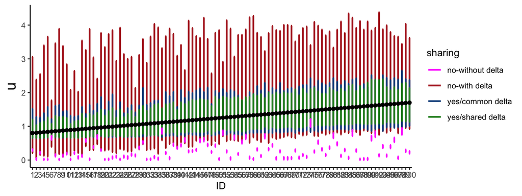

```r
nodelta_cis=m_nwd=matrix(NA,length(u_val),2)
fn_s = function(x) c(quantile(x, probs = c(0.025,0.975)))

for(i in seq_along(u_val)){
  nodelta_cis[i,] = fn_s(lu_no[[i]])
  m_nwd[i,] = fn_s(lu[[i]])
}

ysd_cis=data.frame(t(apply(ex_ysd$u,2,quantile,probs=c(0.025,0.975))))
yes_common_delta=data.frame(t(apply(ex_ycd$u,2,quantile,probs=c(0.025,0.975))))

m_nwd=data.frame(m_nwd)
colnames(m_nwd) = colnames(ysd_cis)
nodelta_cis=data.frame(nodelta_cis)
colnames(nodelta_cis) = colnames(ysd_cis)
m_nwd$u_true = u_val
m_nwd$sharing= "no-with delta"
nodelta_cis$u_true = u_val
nodelta_cis$sharing= "no-without delta"
yes_common_delta$u_true=u_val
yes_common_delta$sharing="yes/common delta"
ysd_cis$u_true=u_val
ysd_cis$sharing="yes/shared delta"

df_CIs = rbind(m_nwd,yes_common_delta,ysd_cis,nodelta_cis)
colnames(df_CIs)[1:2] = c("lower","upper")
df_CIs$id = rep(id,4)

ggplot(df_CIs,aes(x = as.factor(id), y = u_true, ymin = lower, ymax = upper, color=sharing))+
    geom_errorbar(width = 0.3, size=0.9) +
    theme_classic()+
    geom_point(size = 1.5, color="black")+
    ylab("u")+xlab("ID")+
    # annotate("text", x=15, y=4.2, label= "95% CIs", size=6)+
    theme(axis.title.y = element_text(size = rel(1.5)))+
    scale_color_manual(
      breaks=c('no-without delta', 'no-with delta', "yes/common delta", "yes/shared delta"),
      values=c("magenta","firebrick","dodgerblue4", "forestgreen"))
```

```r
df_un_red=df_CIs
df_un_red$ci_length=df_CIs$upper-df_CIs$lower
pl_ci_length=ggplot()+
  geom_boxplot(data=df_un_red, aes(x=sharing, y=ci_length, colour=sharing))+
  theme_classic()+
   scale_color_manual(
      breaks=c('no-without delta', 'no-with delta', "yes/common delta", "yes/shared delta"),
      values=c("magenta","firebrick","dodgerblue4", "forestgreen"))+
  ylab("CI lengths")+
  theme(legend.position="none",
        axis.text=element_text(size=6))
# pl_ci_length
```

- Coverage

```r
df_un_red$coverage=ifelse(df_un_red$lower<=df_un_red$u_true & df_un_red$upper>=df_un_red$u_true,1,0)
shar=unique(df_un_red$sharing)
mean(df_un_red[df_un_red$sharing=="no-without delta","coverage"])
```

```
[1] 0
```

```r
mean(df_un_red[df_un_red$sharing=="no-with delta","coverage"])
```

```
[1] 1
```

```r
mean(df_un_red[df_un_red$sharing=="yes/common delta","coverage"])
```

```
[1] 1
```

```r
mean(df_un_red[df_un_red$sharing=="yes/shared delta","coverage"])
```

```
[1] 1
```

- Reduction in uncertainty compared to not sharing information

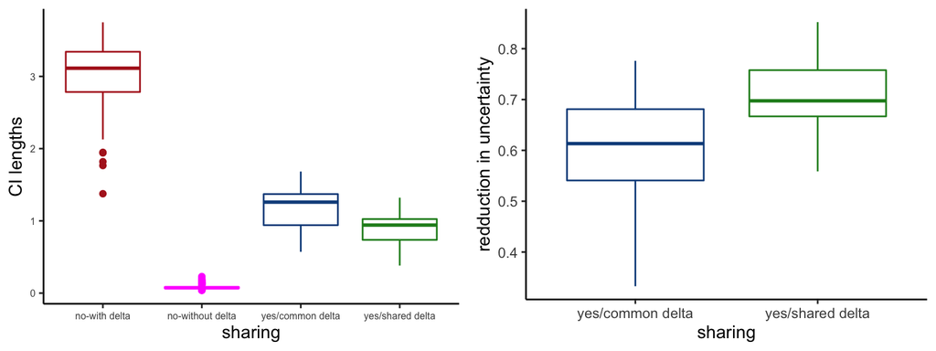

```r
common_delta = (df_un_red$ci_length[df_un_red$sharing == "no-with delta"] - df_un_red$ci_length[df_un_red$sharing == "yes/common delta"])/df_un_red$ci_length[df_un_red$sharing == "no-with delta"]
shared_delta = (df_un_red$ci_length[df_un_red$sharing == "no-with delta"] - df_un_red$ci_length[df_un_red$sharing == "yes/shared delta"])/df_un_red$ci_length[df_un_red$sharing == "no-with delta"]
df_red_plot = data.frame(reduction = c(common_delta, shared_delta), sharing = rep(c("yes/common delta","yes/shared delta"), each=length(u_val)))

pl_red_un=ggplot()+
  geom_boxplot(data=df_red_plot, aes(x=sharing, y=reduction, colour=sharing))+
  theme_classic()+
   scale_color_manual(
      breaks=c("yes/common delta", "yes/shared delta"),
      values=c("dodgerblue4", "forestgreen"))+
  ylab("redduction in uncertainty")+
  theme(legend.position="none")
pl_length__red_un=ggarrange(pl_ci_length, pl_red_un)
pl_length__red_un
```

```r
# ggsave("Figs/large_scale_100.pdf", plot = pl_length__red_un, width = 18, height = 8, units = "cm")
```